# lab2

# Assignment 1

## Step 1

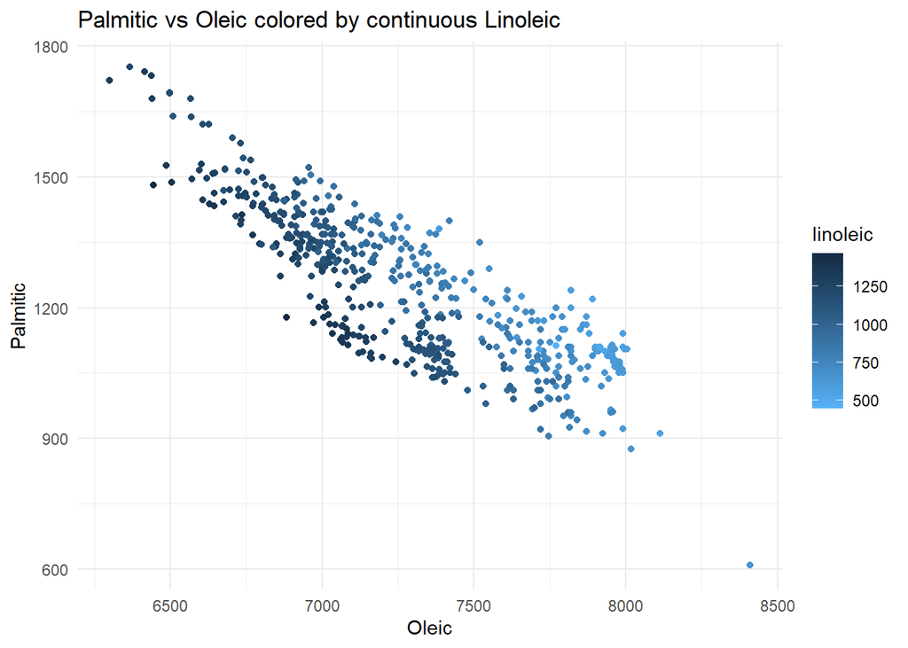

```r
data <- read.csv("olive.csv")
ggplot(data,mapping = aes(x=oleic, y=palmitic, color = linoleic)) +
  geom_point() +
  scale_color_gradient(  low = "#56B1F7",
                         high = "#132B43") +
  labs(title = "Palmitic vs Oleic colored by continuous Linoleic",
       x = "Oleic",
       y = "Palmitic") +
    theme_minimal()
```

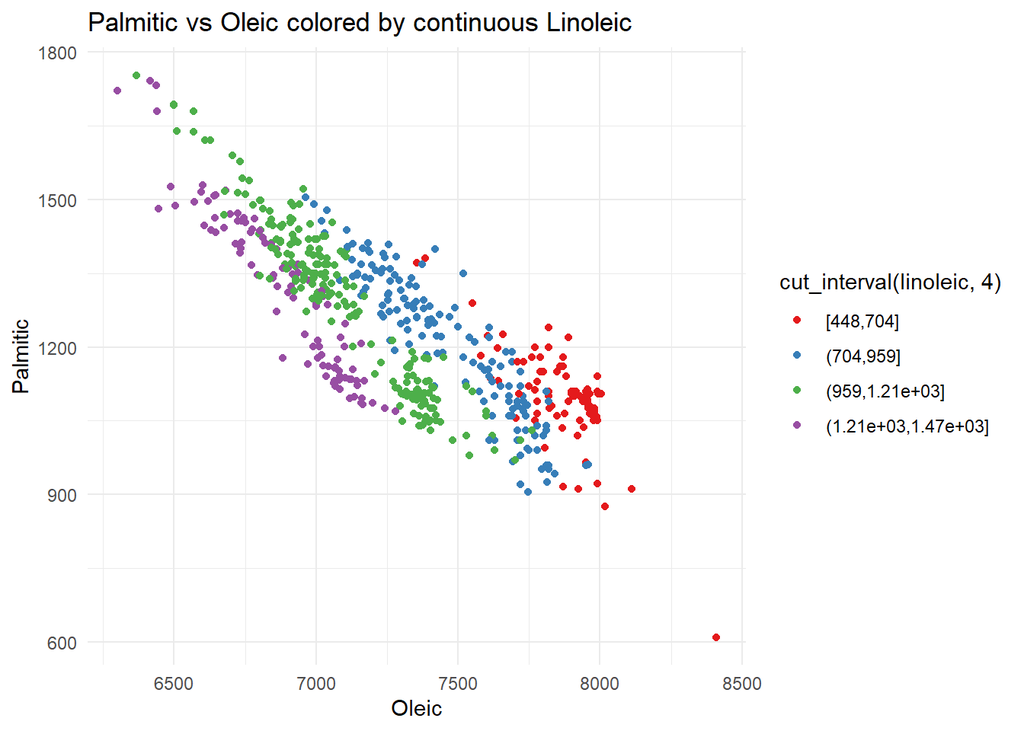

```r
p_color <- ggplot(data,mapping = aes(x=oleic, y=palmitic, color = cut_interval(linoleic,4))) +
  geom_point() +
  scale_color_brewer(palette = "Set1") +
  labs(title = "Palmitic vs Oleic colored by continuous Linoleic",
       x = "Oleic",
       y = "Palmitic") +
  theme_minimal()

p_color
```

When we only use a single color dimension to express numerical values, it captures subtle variations in `Linoleic`. However,human eyes cannot quickly and accurately perceive the numerical differences. When dividing the numerical values into several discrete color, categories becomes a feature of “color classification”, which is easier to be quickly distinguished by pre-attention processing.But it sacrifices detail of underlying trends.

`Perception problem` is demonstrated by this experiment. People perceive differences between distinct colors more accurately than differences in color intensity, because distinguishing different colors is a preattentive visual task, meaning it can be processed quickly and in parallel by the visual system. In contrast, variations in color intensity are more subtle and can easily be misinterpreted.

## Step 2

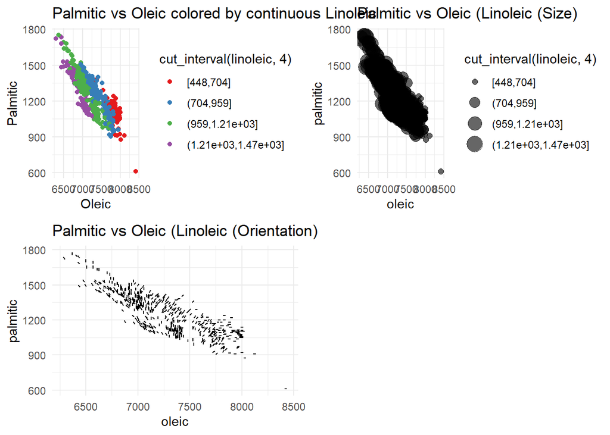

```r
p_size <- ggplot(data, aes(x = oleic, y = palmitic, size = cut_interval(linoleic,4))) +
  geom_point(alpha = 0.6) +
  labs(title = "Palmitic vs Oleic (Linoleic (Size)") +
  theme_minimal()


angles <- c(0, pi/4, pi/2, 3*pi/4)
data <- data %>%
  mutate(Linoleic_angle = as.numeric(cut_interval(linoleic,4)),
         angle = angles[Linoleic_angle])

p_angle <- ggplot(data, aes(x = oleic, y = palmitic)) +
  geom_spoke(aes(angle = angle, radius = 25),
             ) +
  labs(title = "Palmitic vs Oleic (Linoleic (Orientation)") +
  theme_minimal()

grid.arrange(grobs = list(p_color,p_size,p_angle), ncol = 2)
```

When mapping the discretized Linoleic to **size**, the difference between categories can be difficult to perceived. Some of the points are too large and they tend to overlap, making it difficult to distinguish certain categories.In comparison, mapping to **orientation** allows categories to be distinguished more easily, although the precision of decoding is still limited because humans are not as sensitive to small angle differences. Mapping to **color** provides the easiest distinction between categories, as humans can perceive colors more accurately.

## Step 3

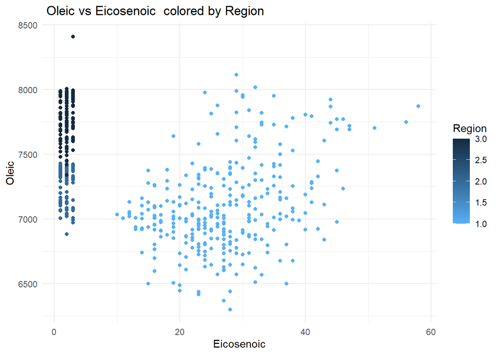

```r
ggplot(data,mapping = aes(x=eicosenoic, y=oleic, color = Region)) +
  geom_point() +
  scale_color_gradient(  low = "#56B1F7",
                         high = "#132B43") +
  labs(title = " Oleic vs Eicosenoic  colored by Region",
       x = "Eicosenoic",
       y = "Oleic") +
  theme_minimal()
```

Region values have no real distance relationship. Using continuous colors will blur the boundaries between categories and produce mixed colors, making it difficult to separate groups at a glance. And it will mislead readers to interpret Region as a numerical variable.

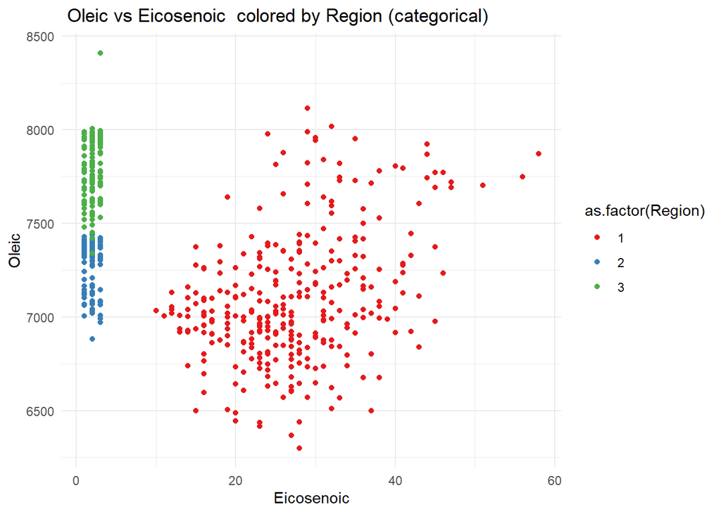

```r
ggplot(data,mapping = aes(x=eicosenoic, y=oleic, color = as.factor(Region))) +
  geom_point() +
  scale_color_brewer(palette = "Set1") +
  labs(title = " Oleic vs Eicosenoic  colored by Region (categorical)",
       x = "Eicosenoic",
       y = "Oleic") +
  theme_minimal()
```

Discrete color coding relies primarily on preattentive mechanisms, which can be rapidly and parallelly processed by the brain, allowing me to quickly discern and immediately perceive the boundaries between different categories.

## Step 4

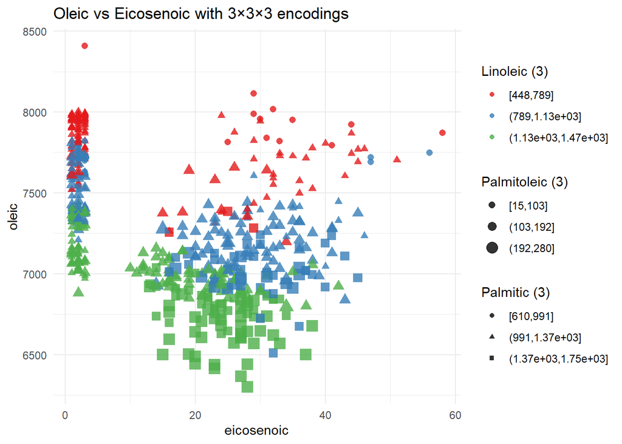

```r
ggplot(data, aes(x=eicosenoic, y=oleic)) +
  geom_point(aes(color =cut_interval(linoleic,3), shape = cut_interval(palmitic,3), size = cut_interval(palmitoleic,3)),
             alpha = 0.8, stroke = 0.3) +
  scale_color_brewer(palette = "Set1") +
  scale_shape_manual(values = c(16, 17, 15)) +
  scale_size_manual(values = c(2.2, 3.2, 4.2)) +
  labs(title = "Oleic vs Eicosenoic with 3×3×3 encodings",
       color = "Linoleic (3)", shape = "Palmitic (3)", size = "Palmitoleic (3)",
       x = "eicosenoic", y = "oleic") +
  theme_minimal()
```

Extremely difficult.

When multiple channels are jointly encoded, it is no longer parallel processing of pre-attention, but requires serial comparison of attention. Combining metrics does not sum up the capacity. So the working memory load is high, making it difficult to distinguish 27 combinations quickly and stably.

## Step 5

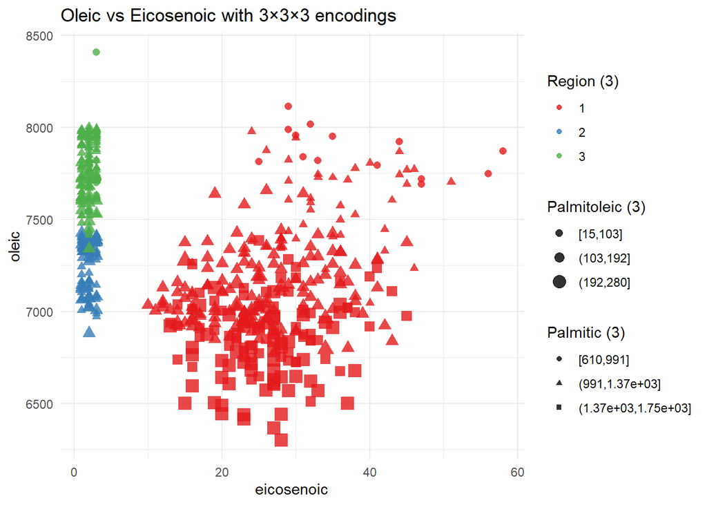

```r
ggplot(data, aes(x=eicosenoic, y=oleic)) +
  geom_point(aes(color =as.factor(Region), shape = cut_interval(palmitic,3), size = cut_interval(palmitoleic,3)),
             alpha = 0.8, stroke = 0.3) +
  scale_color_brewer(palette = "Set1") +
  scale_shape_manual(values = c(16, 17, 15)) +
  scale_size_manual(values = c(2.2, 3.2, 4.2)) +
  labs(title = "Oleic vs Eicosenoic with 3×3×3 encodings",
       color = "Region (3)", shape = "Palmitic (3)", size = "Palmitoleic (3)",
       x = "eicosenoic", y = "oleic") +
  theme_minimal()
```

The boundary between two groups of elements with the same visual feature is detected preattentively.Even though the plot uses multiple aesthetics mapping, we can still capture the boundaries information between regions since color is a strong preattentive feature. This enables the decision boundaries between regions to be readily distinguished without requiring focused attention, as Treisman’s theory suggests.

## Step 6

```r
area_counts <- data %>%
  count(Area, name = "n") %>%
  arrange(desc(n)) %>%
  mutate(pct = n / sum(n))

plot_ly(
  data = area_counts,
  labels = ~Area,
  values = ~n,
  type = "pie",
  textinfo = "none",
  hovertemplate = paste(
    "<b>%{label}</b><br>",
    "Count: %{value}<br>",
    "Share: %{percent}",
    "<extra></extra>"
  )
 ) %>%
  layout(title = "Proportions of oils by Area ",
         showlegend = TRUE)
```

[interactive chart not shown]

The pie chart demonstrates the perceptual limits of judging angles/areas and the cost of hover-only labels, which force attentive, serial inspection rather than rapid, preattentive comparison.

## Step 7

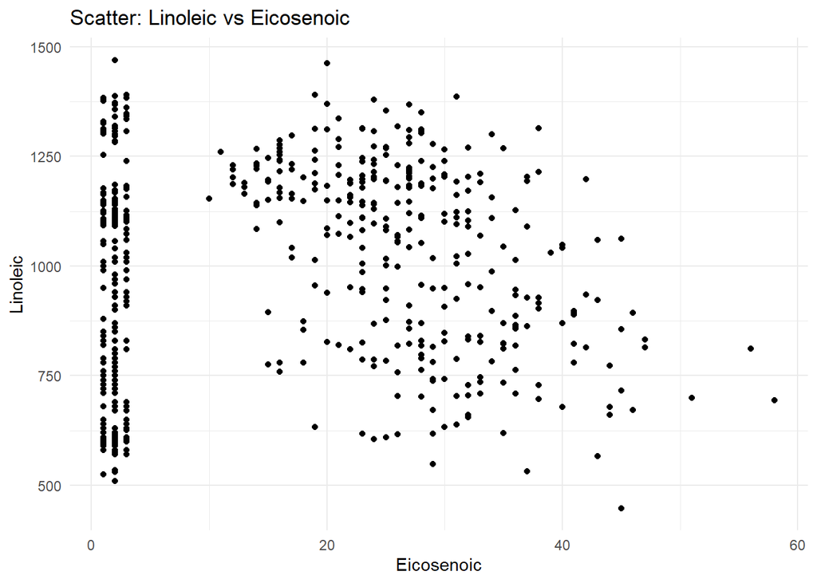

```r
p_scatter <- ggplot(data, aes(x = eicosenoic, y = linoleic)) +
  geom_point() +
  labs(title = "Scatter: Linoleic vs Eicosenoic",
       x = "Eicosenoic", y = "Linoleic") +
  theme_minimal()
p_scatter
```

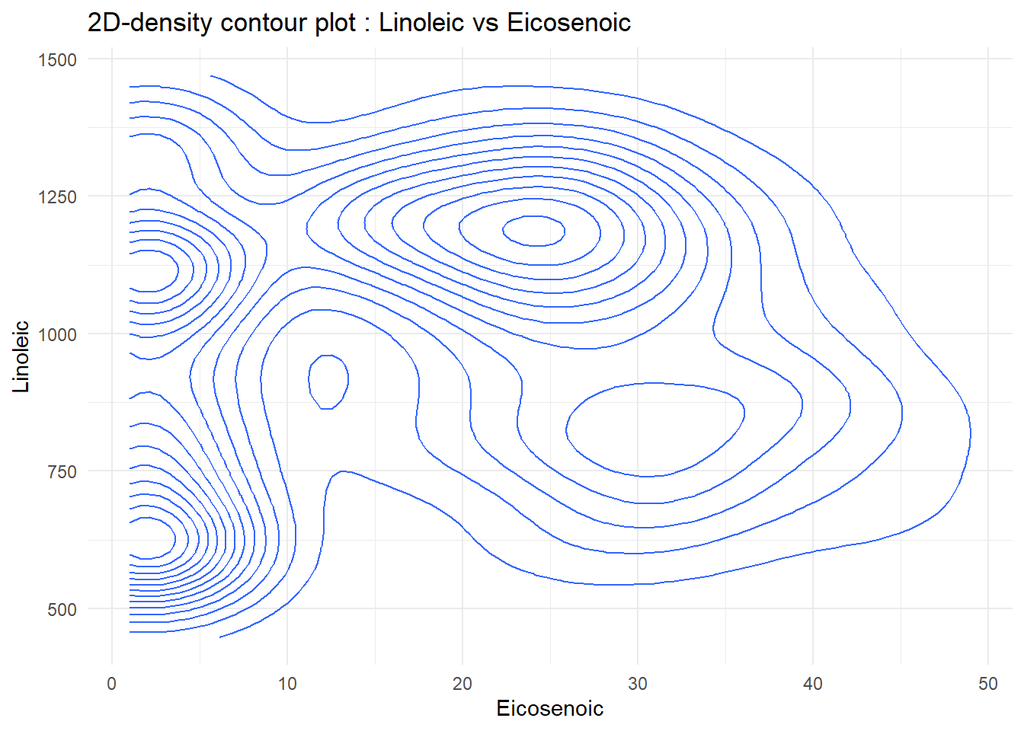

```r
p_contour <- ggplot(data, aes(x = eicosenoic, y = linoleic)) +
  stat_density_2d() +
  scale_color_viridis_d() +
  labs(title = "2D-density contour plot : Linoleic vs Eicosenoic",
       x = "Eicosenoic", y = "Linoleic", color = "ndensity level") +
  theme_minimal()
p_contour
```

Compared to scatterplot, conter plot abstracts the data into density levels, which may be misleading because the counter lines may suggest the presence of distinct cluster or groups even if the data is not categorical.

# Assignment 2

```r
data <- read_xlsx("baseball-2016.xlsx")
```

Yes, MDS is based on distance, but the dimensions of the data variables vary greatly, which will affect the judgment of MDS.

## Step 2

```r
data.numeric= scale(data[,3:28])
d=dist(data.numeric)

res=isoMDS(d,k=2)
```

```r
coords=res$points

coordsMDS=as.data.frame(coords)
coordsMDS$name=rownames(coordsMDS)
coordsMDS$League=data$League
coordsMDS$Team=data$Team


plot_ly(coordsMDS, x=~V1, y=~V2, type="scatter", hovertext=~Team, color= ~League)
```

[interactive chart not shown]

There is a slight difference, but not strong.

AL teams are more distributed above the x-axis and to the right of the y-axis.

NL teams are more distributed below the x-axis and to the right of the y-axis.

Therefore, the two leagues are more distinguishable along the y-axis.

Boston Red Sox seems to be an outlier.

## Step 3

```r
sh <- Shepard(d, coords)
delta <-as.numeric(d)
D<- as.numeric(dist(coords))

n=nrow(coords)
index=matrix(1:n, nrow=n, ncol=n)
index1=as.numeric(index[lower.tri(index)])

n=nrow(coords)
index=matrix(1:n, nrow=n, ncol=n, byrow = T)
index2=as.numeric(index[lower.tri(index)])



plot_ly()%>%
  add_markers(x=~delta, y=~D, hoverinfo = 'text',
              text = ~paste('Obj1: ', rownames(data)[index1],
                            '<br> Obj 2: ', rownames(data)[index2]))%>%
  #if nonmetric MDS inolved
  add_lines(x=~sh$x, y=~sh$yf)
```

[interactive chart not shown]

Relatively successful, as can be seen from the figure, the results fit very well and the points basically fit the curve.

When $\delta$ is between 6 and 8, a few points are below the line, indicating that the distance between these points after mapping is too close.

When $\delta$ is between 8 and 10, a few points are above the line, indicating that the distance between these points after mapping is too far.

When $\delta$ is greater than 10, almost all points are difficult to map for MDS.

`Minnesota Twins` and `Aizona Diamondbacks` were hard to map successfully.

## Step 4

```r
best_dim <- "V2"

num_df <- data[, 3:28]
num_names <- names(num_df)


cors <- sapply(num_names, function(vname) {
  cor(num_df[[vname]], coordsMDS[[best_dim]], use = "complete.obs", method = "pearson")
})

cors_sorted <- sort(cors, decreasing = FALSE)
top2 <- names(sort(abs(cors), decreasing = TRUE))[1:2]
print(cors[top2])
```

```
##          HR HR.per.game
##   0.7079577   0.7068067
```

```r
plot_ly(coordsMDS, x=~V2, y=~num_df[[top2[1]]], type="scatter", hovertext=~Team, color= ~League) %>%
    layout(
      xaxis = list(title = best_dim),
      yaxis = list(title = top2[1])
    )
```

[interactive chart not shown]

```r
plot_ly(coordsMDS, x=~V2, y=~num_df[[top2[2]]], type="scatter", hovertext=~Team, color= ~League)  %>%
    layout(
      xaxis = list(title = best_dim),
      yaxis = list(title = top2[2])
    )
```

[interactive chart not shown]

HR and HR per game showed the strongest positive correlation.

Home runs are a significant predictor of both scoring and winning percentage, so V2 can be interpreted as a dimension of team offensive intensity, with significant differences across leagues.

# Appendix

## Assignmen1

```r
library(ggplot2)
library(dplyr)
library(gridExtra)
library(plotly)

data <- read.csv("olive.csv")

# step1

ggplot(data,mapping = aes(x=oleic, y=palmitic, color = linoleic)) +
  geom_point() +
  scale_color_gradient(  low = "#56B1F7",
                         high = "#132B43") +
  labs(title = "Palmitic vs Oleic colored by continuous Linoleic",
       x = "Oleic",
       y = "Palmitic") +
    theme_minimal()


p_color <- ggplot(data,mapping = aes(x=oleic, y=palmitic, color = cut_interval(linoleic,4))) +
  geom_point() +
  scale_color_brewer(palette = "Set1") +
  labs(title = "Palmitic vs Oleic colored by continuous Linoleic",
       x = "Oleic",
       y = "Palmitic") +
  theme_minimal()

p_color
#When we only use a single color dimension to express numerical values,
#the human eye cannot quickly and accurately perceive the numerical differences.
#However, dividing the numerical values into several discrete color categories becomes a feature of "color classification",
#which is easier to be quickly distinguished by pre-attention processing.

# step2

# color class is as previous plot.

p_size <- ggplot(data, aes(x = oleic, y = palmitic, size = cut_interval(linoleic,4))) +
  geom_point(alpha = 0.6) +
  labs(title = "Palmitic vs Oleic (Linoleic (Size)") +
  theme_minimal()


angles <- c(0, pi/4, pi/2, 3*pi/4)
data <- data %>%
  mutate(Linoleic_angle = as.numeric(cut_interval(linoleic,4)),
         angle = angles[Linoleic_angle])

p_angle <- ggplot(data, aes(x = oleic, y = palmitic)) +
  geom_spoke(aes(angle = angle, radius = 25),
             ) +
  labs(title = "Palmitic vs Oleic (Linoleic (Orientation)") +
  theme_minimal()

grid.arrange(grobs = list(p_color,p_size,p_angle), ncol = 2)
#

# step3
ggplot(data,mapping = aes(x=eicosenoic, y=oleic, color = Region)) +
  geom_point() +
  scale_color_gradient(  low = "#56B1F7",
                         high = "#132B43") +
  labs(title = " Oleic vs Eicosenoic  colored by Region",
       x = "Eicosenoic",
       y = "Oleic") +
  theme_minimal()
#Region values have no real distance relationship.
#Using continuous colors will blur the boundaries between categories and produce mixed colors, making it difficult to separate groups at a glance.
#And it will mislead readers to interpret Region as a numerical variable.

ggplot(data,mapping = aes(x=eicosenoic, y=oleic, color = as.factor(Region))) +
  geom_point() +
  scale_color_brewer(palette = "Set1") +
  labs(title = " Oleic vs Eicosenoic  colored by Region (categorical)",
       x = "Eicosenoic",
       y = "Oleic") +
  theme_minimal()
#Discrete color coding relies primarily on preattentive mechanisms, so I can quickly discern boundaries.

# step4
ggplot(data, aes(x=eicosenoic, y=oleic)) +
  geom_point(aes(color =cut_interval(linoleic,3), shape = cut_interval(palmitic,3), size = cut_interval(palmitoleic,3)),
             alpha = 0.8, stroke = 0.3) +
  scale_color_brewer(palette = "Set1") +
  scale_shape_manual(values = c(16, 17, 15)) +
  scale_size_manual(values = c(2.2, 3.2, 4.2)) +
  labs(title = "Oleic vs Eicosenoic with 3×3×3 encodings",
       color = "Linoleic (3)", shape = "Palmitic (3)", size = "Palmitoleic (3)",
       x = "eicosenoic", y = "oleic") +
  theme_minimal()
# Extremely difficult.
# When multiple channels are jointly encoded, it is no longer parallel processing of pre-attention, but requires serial comparison of attention.
# Combining metrics does not sum up the capacity. So the working memory load is high, making it difficult to distinguish 27 combinations quickly and stably.

# step5
ggplot(data, aes(x=eicosenoic, y=oleic)) +
  geom_point(aes(color =as.factor(Region), shape = cut_interval(palmitic,3), size = cut_interval(palmitoleic,3)),
             alpha = 0.8, stroke = 0.3) +
  scale_color_brewer(palette = "Set1") +
  scale_shape_manual(values = c(16, 17, 15)) +
  scale_size_manual(values = c(2.2, 3.2, 4.2)) +
  labs(title = "Oleic vs Eicosenoic with 3×3×3 encodings",
       color = "Region (3)", shape = "Palmitic (3)", size = "Palmitoleic (3)",
       x = "eicosenoic", y = "oleic") +
  theme_minimal()
# Boundary between two groups of elements with the same visual feature is detected preattentively.

# step6
area_counts <- data %>%
  count(Area, name = "n") %>%
  arrange(desc(n)) %>%
  mutate(pct = n / sum(n))

plot_ly(
  data = area_counts,
  labels = ~Area,
  values = ~n,
  type = "pie",
  textinfo = "none",
  hovertemplate = paste(
    "<b>%{label}</b><br>",
    "Count: %{value}<br>",
    "Share: %{percent}",
    "<extra></extra>"
  )
 ) %>%
  layout(title = "Proportions of oils by Area ",
         showlegend = TRUE)

#The pie chart demonstrates the perceptual limits of judging angles/areas and the cost of hover-only labels, which force attentive, serial inspection rather than rapid, preattentive comparison.

p_scatter <- ggplot(data, aes(x = eicosenoic, y = linoleic)) +
  geom_point() +
  labs(title = "Scatter: Linoleic vs Eicosenoic",
       x = "Eicosenoic", y = "Linoleic") +
  theme_minimal()
p_scatter

p_contour <- ggplot(data, aes(x = eicosenoic, y = linoleic)) +
  stat_density_2d() +
  scale_color_viridis_d() +
  labs(title = "2D-density contour plot : Linoleic vs Eicosenoic",
       x = "Eicosenoic", y = "Linoleic", color = "ndensity level") +
  theme_minimal()
p_contour

#
```

## Assignmen 2

```r
library(readxl)
library(plotly)
library(MASS)
library(dplyr)
library(tidyr)
library(gridExtra)

data <- read_xlsx("baseball-2016.xlsx")
#MDS is based on distance, but the dimensions of the data variables vary greatly, which will affect the judgment of MDS.

#step2

data.numeric= scale(data[,3:28])
d=dist(data.numeric)

res=isoMDS(d,k=2)
coords=res$points

coordsMDS=as.data.frame(coords)
coordsMDS$name=rownames(coordsMDS)
coordsMDS$League=data$League
coordsMDS$Team=data$Team


plot_ly(coordsMDS, x=~V1, y=~V2, type="scatter", hovertext=~Team, color= ~League)

#There is a slight difference, but not strong.
#AL teams are more distributed above the x-axis and to the right of the y-axis.
#NL teams are more distributed below the x-axis and to the right of the y-axis.
#Therefore, the two leagues are more distinguishable along the y-axis.
# Boston Red Sox seems to be an outlier.

#step3


sh <- Shepard(d, coords)
delta <-as.numeric(d)
D<- as.numeric(dist(coords))

n=nrow(coords)
index=matrix(1:n, nrow=n, ncol=n)
index1=as.numeric(index[lower.tri(index)])

n=nrow(coords)
index=matrix(1:n, nrow=n, ncol=n, byrow = T)
index2=as.numeric(index[lower.tri(index)])



plot_ly()%>%
  add_markers(x=~delta, y=~D, hoverinfo = 'text',
              text = ~paste('Obj1: ', rownames(data)[index1],
                            '<br> Obj 2: ', rownames(data)[index2]))%>%
  #if nonmetric MDS inolved
  add_lines(x=~sh$x, y=~sh$yf)

# relatively successful, as can be seen from the figure, the results fit very well and the points basically fit the curve.
# When $delta$ is between 6 and 8, a few points are below the line, indicating that the distance between these points after mapping is too close.
# When $delta$ is between 8 and 10, a few points are above the line, indicating that the distance between these points after mapping is too far.
# When $delta$ is greater than 10, almost all points are difficult to map for MDS.

#step4
best_dim <- "V2"

num_df <- data[, 3:28]
num_names <- names(num_df)


cors <- sapply(num_names, function(vname) {
  cor(num_df[[vname]], coordsMDS[[best_dim]], use = "complete.obs", method = "pearson")
})

cors_sorted <- sort(cors, decreasing = FALSE)
top2 <- names(sort(abs(cors), decreasing = TRUE))[1:2]
print(cors[top2])

plot_ly(coordsMDS, x=~V2, y=~num_df[[top2[1]]], type="scatter", hovertext=~Team, color= ~League) %>%
  layout(
    xaxis = list(title = best_dim),
    yaxis = list(title = top2[1])
  )

plot_ly(coordsMDS, x=~V2, y=~num_df[[top2[2]]], type="scatter", hovertext=~Team, color= ~League)  %>%
  layout(
    xaxis = list(title = best_dim),
    yaxis = list(title = top2[2])
  )
#HR and HR per game showed the strongest positive correlation.
#Home runs are a significant predictor of both scoring and winning percentage, so V2 can be interpreted as a dimension of team offensive intensity, with significant differences across leagues.
```